[figure not shown]

[figure not shown]

# OVERVIEW

Financial Analytics Workflow

1. What decision(s) are we making?
2. What questions do we need to ask to support this decision?
3. What data do we need?
4. What tools do we need?
5. How do we communicate what we’ve learned to help inform this decision?

Data We Might Need/Use (outside of our stand)

1. Macroeconomic data:
- GDP
- inflation
- wages
- population
2. Financial data:
- stock market prices
- bond prices
- exchange rates
- commodity prices

# UNIT 1

# UNIT 2

# UNIT 3

# UNIT 3: Macrofinancial Data Analysis

### The Scenario

My friend in the neighboring town needs help with her lemonade stand. She offers me part of her stand in exchange for my assistance.

First, I ask her to:

1. Get data about her neighborhood
2. Compare her neighborhood to my neighborhood
3. Generate scenarios that might happen that would impact our stands (baseball games, garage sales etc.)

### The Example

1. DECISION: Supply something new to this market
- PRODUCT: Lemon Concentrate Cubes
- GEOGRAPHY: One town over
- CUSTOMERS: Soccer moms, little leaguers, business professionals en-route to work
2. QUESTIONS:
- How will the performance of the secondary stand affect the size and timing of Lemon Concentrate Cube orders?
- How will the value of Lemon Concentrate Cubes affect the value of my stand?
- How will the fact that the secondary stand uses Apple Pay impact my stand and overall earnings?
3. DATA:
- something to represent volatility and correlation
- something to represent volatility
- exchange rates

(non lemonade examples) - stock prices - oil prices - USD/EUR exchange rates

### The Code

1. Load data
2. Format dates
3. Create a time series object

```r
library(fBasics)
library(evir)
library(qrmdata)
library(zoo)
data(OIL_Brent)
candy <- OIL_Brent
str(candy)
```

```
An 'xts' object on 1987-05-20/2015-12-28 containing:
  Data: num [1:7258, 1] 18.6 18.4 18.6 18.6 18.6 ...
 - attr(*, "dimnames")=List of 2
  ..$ : NULL
  ..$ : chr "OIL_Brent"
  Indexed by objects of class: [Date] TZ: UTC
  xts Attributes:
 NULL
```

4. Compute rates of change for oil prices

*LEMONADE STAND: Use our volitility metric (candy prices) to give us an overview of this market*

```r
candy_price <- as.zoo(candy)
colnames(candy_price) <- "candy"
head(candy_price, n=5)
```

```
           candy
1987-05-20 18.63
1987-05-21 18.45
1987-05-22 18.55
1987-05-25 18.60
1987-05-26 18.63
```

```r
candy_log <- log(candy_price)
head(candy_log, n=5)
```

```
              candy
1987-05-20 2.924773
1987-05-21 2.915064
1987-05-22 2.920470
1987-05-25 2.923162
1987-05-26 2.924773
```

```r
candy_difference <- diff(candy_log)
head(candy_difference, n=5)
```

```
                  candy
1987-05-21 -0.009708814
1987-05-22  0.005405419
1987-05-25  0.002691792
1987-05-26  0.001611604
1987-05-27 -0.001611604
```

```r
candy_return <- candy_difference[-1]*100
# in one line
# candy_return <- diff(log(candy_price))[-1]*100

colnames(candy_return) <- "candy_return"
print('HEAD')
```

```
[1] "HEAD"
```

```r
head(candy_return, n=5)
```

```
           candy_return
1987-05-22    0.5405419
1987-05-25    0.2691792
1987-05-26    0.1611604
1987-05-27   -0.1611604
1987-05-28    0.0000000
```

```r
print('TAIL')
```

```
[1] "TAIL"
```

```r
tail(candy_return, n=5)
```

```
           candy_return
2015-12-21   -3.9394831
2015-12-22   -0.2266290
2015-12-23    1.4919348
2015-12-24    3.9177726
2015-12-28   -0.3768511
```

5. Visualize this candy data with box plots and autocorrelation functions

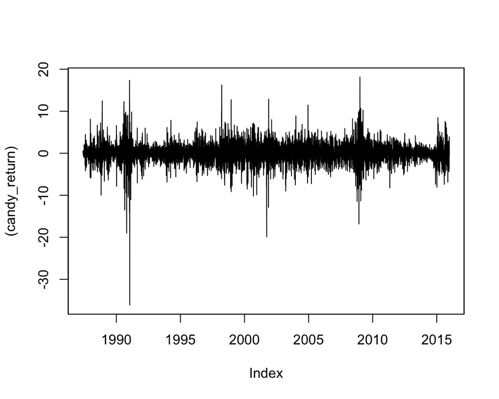

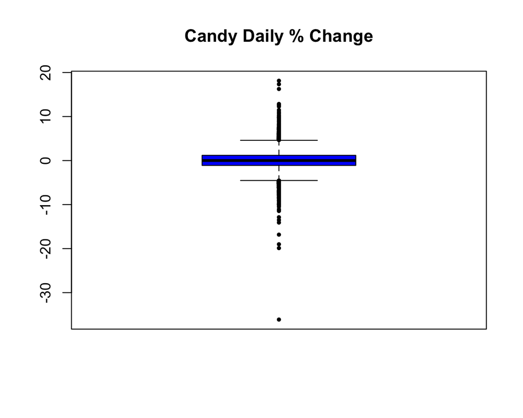

6. Look at persistence

```
# autocorrelation
acf(coredata(candy_return),
    main = "Candy Daily Autocorrelogram",
    lag.max = 20, ylab = "", xlab = "", col = "blue", ci.col = "red")

# partial autocorrelation
pacf(coredata(candy_return),
     main = "Candy Daily Partial Autocorrelogram",
     lag.max = 20, ylab = "", xlab = "", col = "blue", ci.col = "red")
```

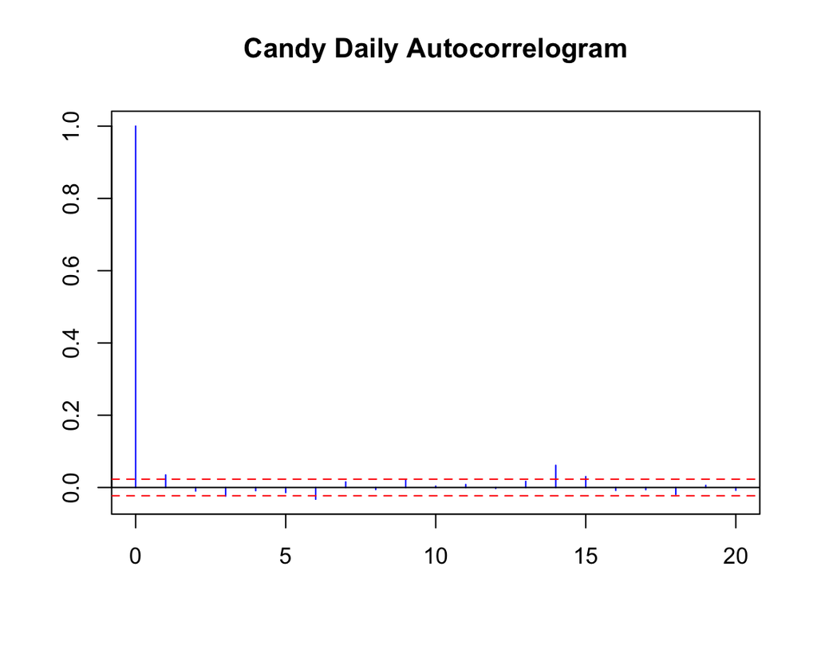

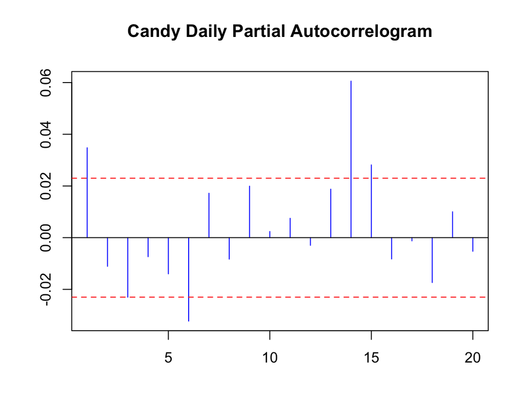

NOTES:

# LEARNING THE HARD WAY

Stylized Facts of the Market

- Financial stock, bond, commodity etc. have highly interdependent relationships
- Volatility is rarely constant and often has a structure (*mean reversion*) and is often dependent on the past
- Past shocks persist
- Extreme events are likely to happen with other extreme events
- Negative returns are more likely than positive returns (left skew)